# Anirban_NLP_Project_Full_Code

## **Problem Statement**

### Business Context

The prices of the stocks of companies listed under a global exchange are influenced by a variety of factors, with the company's financial performance, innovations and collaborations, and market sentiment being factors that play a significant role. News and media reports can rapidly affect investor perceptions and, consequently, stock prices in the highly competitive financial industry. With the sheer volume of news and opinions from a wide variety of sources, investors and financial analysts often struggle to stay updated and accurately interpret its impact on the market. As a result, investment firms need sophisticated tools to analyze market sentiment and integrate this information into their investment strategies.

### Problem Definition

With an ever-rising number of news articles and opinions, an investment startup aims to leverage artificial intelligence to address the challenge of interpreting stock-related news and its impact on stock prices. They have collected historical daily news for a specific company listed under NASDAQ, along with data on its daily stock price and trade volumes.

As a member of the Data Science and AI team in the startup, you have been tasked with analyzing the data, developing an AI-driven sentiment analysis system that will automatically process and analyze news articles to gauge market sentiment, and summarizing the news at a weekly level to enhance the accuracy of their stock price predictions and optimize investment strategies. This will empower their financial analysts with actionable insights, leading to more informed investment decisions and improved client outcomes.

### Data Dictionary

- `Date` : The date the news was released
- `News` : The content of news articles that could potentially affect the company's stock price
- `Open` : The stock price (in $) at the beginning of the day
- `High` : The highest stock price (in $) reached during the day
- `Low` : The lowest stock price (in $) reached during the day
- `Close` : The adjusted stock price (in $) at the end of the day
- `Volume` : The number of shares traded during the day
- `Label` : The sentiment polarity of the news content
  - 1: positive
  - 0: neutral
  - -1: negative

## **Installing and Importing Necessary Libraries**

```python
# installing the sentence-transformers and gensim libraries for word embeddings
%pip install -U sentence-transformers gensim transformers tqdm -q
```

```python
# To manipulate and analyze data
import pandas as pd
import numpy as np

# To visualize data
import matplotlib.pyplot as plt
import seaborn as sns

# To used time-related functions
import time

# To parse JSON data
import json

# To build, tune, and evaluate ML models
from sklearn.ensemble import GradientBoostingClassifier
from sklearn.ensemble import RandomForestClassifier

from sklearn.model_selection import GridSearchCV
from sklearn.metrics import (
    confusion_matrix,
    accuracy_score,
    f1_score,
    precision_score,
    recall_score,
)

# To load/create word embeddings
from gensim.models import Word2Vec
from gensim.models import KeyedVectors
from gensim.scripts.glove2word2vec import glove2word2vec

# To work with transformer models
import torch
from sentence_transformers import SentenceTransformer

# To implement progress bar related functionalities
from tqdm import tqdm

tqdm.pandas()

# To ignore unnecessary warnings
import warnings

warnings.filterwarnings("ignore")
```

[output not shown]

## **Loading the dataset**

```python
# Now let's import and put the train and test datasets in  pandas dataframe
folderPath = "./inputs"

stock_news = pd.read_csv(
    folderPath + "/stock_news.csv"
)  # Complete the code to read the CSV file.
```

```python
# Creating a copy of the dataset
stock = stock_news.copy()
```

## **Data Overview**

```python
stock.head(5)
# Complete the code to check the first 5 rows of the data
```

|  | Date | News | Open | High | Low | Close | Volume | Label |
| --- | --- | --- | --- | --- | --- | --- | --- | --- |
| 0 | 2019-01-02 | The tech sector experienced a significant dec... | 41.740002 | 42.244999 | 41.482498 | 40.246914 | 130672400 | -1 |
| 1 | 2019-01-02 | Apple lowered its fiscal Q1 revenue guidance ... | 41.740002 | 42.244999 | 41.482498 | 40.246914 | 130672400 | -1 |
| 2 | 2019-01-02 | Apple cut its fiscal first quarter revenue fo... | 41.740002 | 42.244999 | 41.482498 | 40.246914 | 130672400 | -1 |
| 3 | 2019-01-02 | This news article reports that yields on long... | 41.740002 | 42.244999 | 41.482498 | 40.246914 | 130672400 | -1 |
| 4 | 2019-01-02 | Apple's revenue warning led to a decline in U... | 41.740002 | 42.244999 | 41.482498 | 40.246914 | 130672400 | -1 |

```python
stock.info
```

```
<bound method DataFrame.info of            Date                                               News       Open  \
0    2019-01-02   The tech sector experienced a significant dec...  41.740002
1    2019-01-02   Apple lowered its fiscal Q1 revenue guidance ...  41.740002
2    2019-01-02   Apple cut its fiscal first quarter revenue fo...  41.740002
3    2019-01-02   This news article reports that yields on long...  41.740002
4    2019-01-02   Apple's revenue warning led to a decline in U...  41.740002
..          ...                                                ...        ...
344  2019-04-30   Media mogul Oprah Winfrey, known for influenc...  50.764999
345  2019-04-30   European shares fell on Tuesday, with banks u...  50.764999
346  2019-04-30   This article reports that the S&P 500 reached...  50.764999
347  2019-04-30   The Federal Reserve is anticipated to keep in...  50.764999
348  2019-04-30   In the first quarter, South Korea's Samsung E...  50.764999

          High        Low      Close     Volume  Label
0    42.244999  41.482498  40.246914  130672400     -1
1    42.244999  41.482498  40.246914  130672400     -1
2    42.244999  41.482498  40.246914  130672400     -1
3    42.244999  41.482498  40.246914  130672400     -1
4    42.244999  41.482498  40.246914  130672400     -1
..         ...        ...        ...        ...    ...
344  50.849998  49.777500  48.708790  186139600     -1
345  50.849998  49.777500  48.708790  186139600     -1
346  50.849998  49.777500  48.708790  186139600     -1
347  50.849998  49.777500  48.708790  186139600     -1
348  50.849998  49.777500  48.708790  186139600      0

[349 rows x 8 columns]>
```

```python
stock.dtypes
```

```
Date       object
News       object
Open      float64
High      float64
Low       float64
Close     float64
Volume      int64
Label       int64
dtype: object
```

```python
stock["Date"] = pd.to_datetime(
    stock["Date"]
)  # to convert the 'Date' column in the 'stock' DataFrame to datetime format.
```

```python
stock.describe().T
```

|  | count | mean | std | min | 25% | 50% | 75% | max |
| --- | --- | --- | --- | --- | --- | --- | --- | --- |
| Open | 349.0 | 4.622923e+01 | 6.442817e+00 | 3.756750e+01 | 4.174000e+01 | 4.597500e+01 | 5.070750e+01 | 6.681750e+01 |
| High | 349.0 | 4.670046e+01 | 6.507321e+00 | 3.781750e+01 | 4.224500e+01 | 4.602500e+01 | 5.085000e+01 | 6.706250e+01 |
| Low | 349.0 | 4.574539e+01 | 6.391976e+00 | 3.730500e+01 | 4.148250e+01 | 4.564000e+01 | 4.977750e+01 | 6.586250e+01 |
| Close | 349.0 | 4.492632e+01 | 6.398338e+00 | 3.625413e+01 | 4.024691e+01 | 4.459692e+01 | 4.911079e+01 | 6.480523e+01 |
| Volume | 349.0 | 1.289482e+08 | 4.317031e+07 | 4.544800e+07 | 1.032720e+08 | 1.156272e+08 | 1.511252e+08 | 2.444392e+08 |
| Label | 349.0 | -5.444126e-02 | 7.151192e-01 | -1.000000e+00 | -1.000000e+00 | 0.000000e+00 | 0.000000e+00 | 1.000000e+00 |

```python
stock.duplicated().sum
# Complete the code to check the duplicate values
```

```
<bound method NDFrame._add_numeric_operations.<locals>.sum of 0      False
1      False
2      False
3      False
4      False
       ...
344    False
345    False
346    False
347    False
348    False
Length: 349, dtype: bool>
```

```python
stock.isnull().sum()
```

```
Date      0
News      0
Open      0
High      0
Low       0
Close     0
Volume    0
Label     0
dtype: int64
```

## **Exploratory Data Analysis**

### Univariate Analysis

- Distribution of individual variables
- Compute and check the distribution of the length of news content

#### Observations on Label

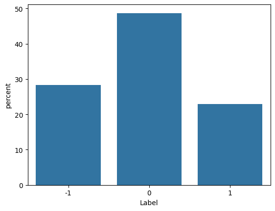

```python
sns.countplot(data=stock, x="Label", stat="percent")
```

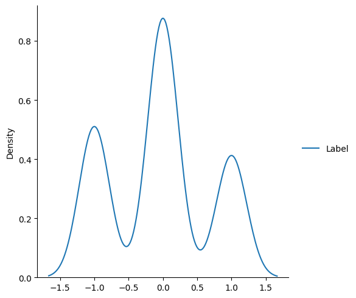

```python
sns.displot(data=stock[["Label"]], kind="kde", palette="tab10")
# Complete the code to plot a density plot of ["Open","High","Low","Close"] all in a single plot
```

#### Observations on Volume

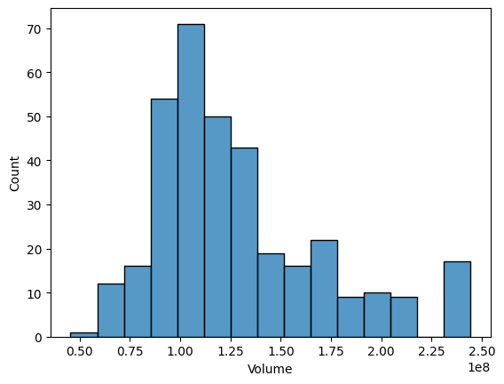

```python
sns.histplot(stock, x="Volume")
# Complete the code to plot a histogram of Volume
```

#### Observations on News length

```python
# Calculating the total number of words present in the news content.
stock["news_len"] = stock["News"].apply(lambda x: len(x.split(" ")))


stock["news_len"].describe()
# Complete the code to print the statistical summary for the news content length
```

```
count    349.000000
mean      49.312321
std        5.727770
min       19.000000
25%       46.000000
50%       50.000000
75%       53.000000
max       61.000000
Name: news_len, dtype: float64
```

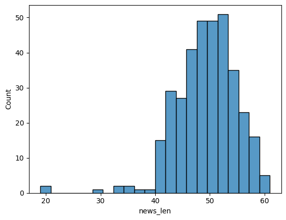

```python
sns.histplot(data=stock, x="news_len")
# Complete the code to plot a histogram of news_len column
```

### Bivariate Analysis

- Correlation
- Sentiment Polarity vs Price
- Date vs Price

**Note**: The above points are listed to provide guidance on how to approach bivariate analysis. Analysis has to be done beyond the above listed points to get maximum scores.

```python
cols_list = stock.select_dtypes(include=np.number).columns.tolist()
cols_list
```

```
['Open', 'High', 'Low', 'Close', 'Volume', 'Label', 'news_len']
```

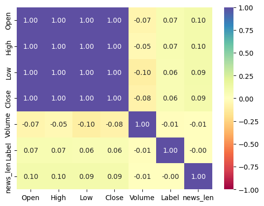

```python
sns.heatmap(
    stock[cols_list].corr(), annot=True, vmin=-1, vmax=1, fmt=".2f", cmap="Spectral"
)
# Complete the code to plot the correlation matrix for numeric columns only.
```

#### Label vs Price (Open, High, Low, Close)

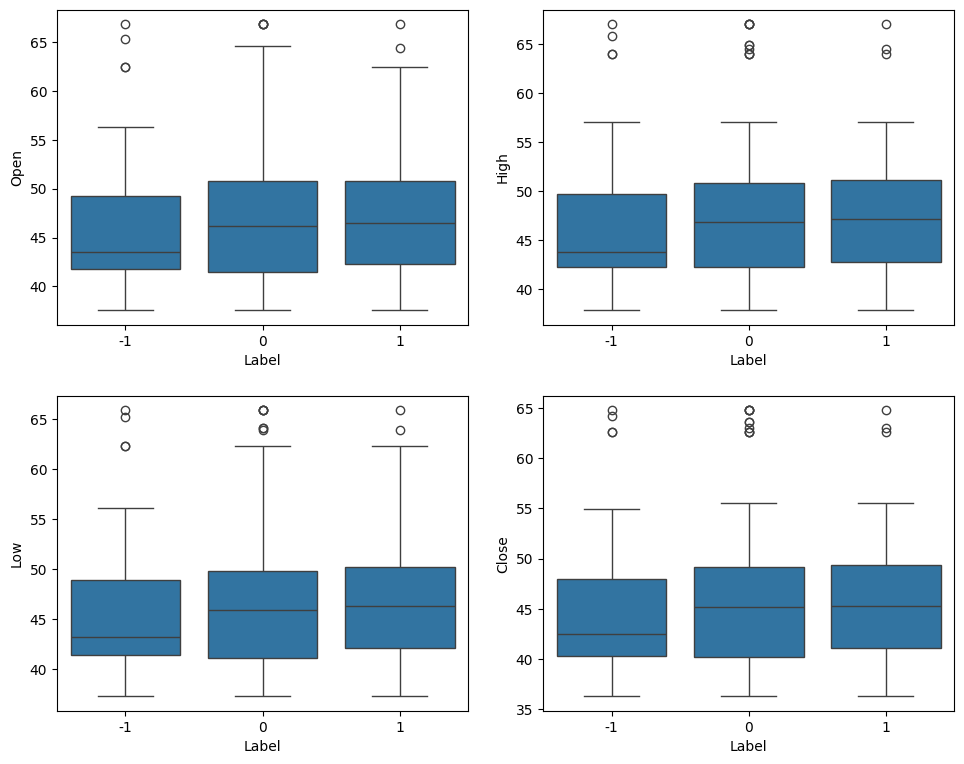

```python
plt.figure(figsize=(10, 8))

for i, variable in enumerate(["Open", "High", "Low", "Close"]):
    plt.subplot(2, 2, i + 1)
    sns.boxplot(data=stock, x="Label", y=variable)
    plt.tight_layout(pad=2)

plt.show()
```

#### Label vs Volume

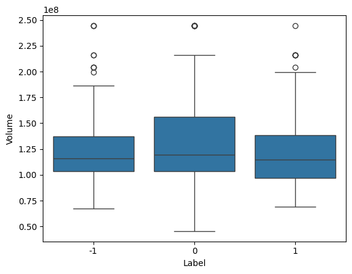

```python
sns.boxplot(
    data=stock,
    x="Label",
    y="Volume",
    # Complete the code to plot a boxplot of Label vs Volume
)
```

#### Date vs Price (Open, High, Low, Close)

```python
stock_daily = (
    stock.groupby("Date")
    .agg(
        {
            "Open": "mean",
            "High": "mean",
            "Low": "mean",
            "Close": "mean",
            "Volume": "mean",
        }
    )
    .reset_index()
)  # Group the 'stocks' DataFrame by the 'Date' column

stock_daily.set_index("Date", inplace=True)
stock_daily.head()
```

| Date | Open | High | Low | Close | Volume |
| --- | --- | --- | --- | --- | --- |
| 2019-01-02 | 41.740002 | 42.244999 | 41.482498 | 40.246914 | 130672400.0 |
| 2019-01-03 | 43.570000 | 43.787498 | 43.222500 | 42.470604 | 103544800.0 |
| 2019-01-04 | 47.910000 | 47.919998 | 47.095001 | 46.419842 | 111448000.0 |
| 2019-01-07 | 50.792500 | 51.122501 | 50.162498 | 49.110790 | 109012000.0 |
| 2019-01-08 | 53.474998 | 54.507500 | 51.685001 | 50.787209 | 216071600.0 |

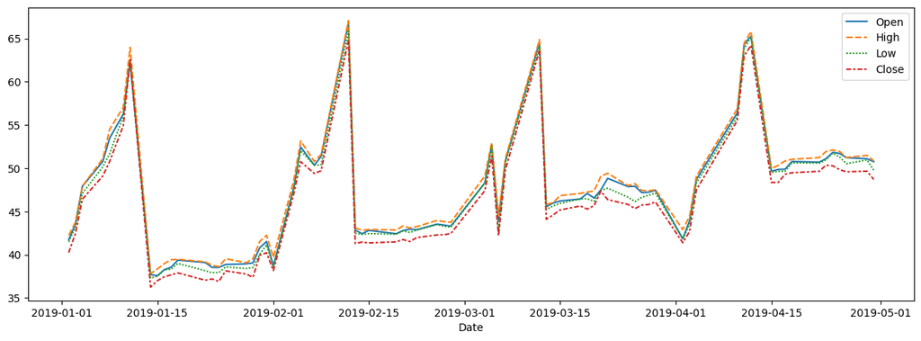

```python
plt.figure(figsize=(15, 5))
sns.lineplot(stock_daily.drop("Volume", axis=1))
# Complete the code to plot a lineplot of all the variables except Volume
```

#### Volume vs Close Price

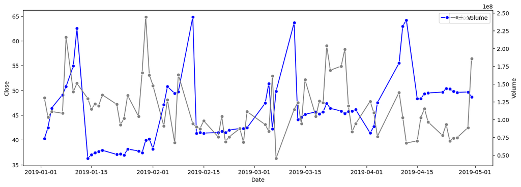

```python
# Create a figure and axis
fig, ax1 = plt.subplots(figsize=(15, 5))

# Lineplot on primary y-axis
sns.lineplot(
    data=stock_daily.reset_index(),
    x="Date",
    y="Close",
    ax=ax1,
    color="blue",
    marker="o",
    label="Close Price",
)

# Create a secondary y-axis
ax2 = ax1.twinx()

# Lineplot on secondary y-axis
sns.lineplot(
    data=stock_daily.reset_index(),
    x="Date",
    y="Volume",
    ax=ax2,
    color="gray",
    marker="o",
    label="Volume",
)

ax1.legend(bbox_to_anchor=(1, 1))
```

## **Data Preprocessing**

```python
stock["Date"].describe()
# Complete the code to print the statistical summary of the 'Date' column
```

```
count                     349
unique                     71
top       2019-01-03 00:00:00
freq                       28
first     2019-01-02 00:00:00
last      2019-04-30 00:00:00
Name: Date, dtype: object
```

### Train-test-validation Split

```python
X_train = stock[
    (stock["Date"] < "2019-04-01")
].reset_index()  # Complete the code to select all rows where the 'Date' is before '2019-04-01'
X_val = stock[
    (stock["Date"] >= "2019-04-01") & (stock["Date"] < "2019-04-16")
].reset_index()  # Complete the code to select all rows where the 'Date' is from '2019-04-01 to '2019-04-16' (excluded)
X_test = stock[
    stock["Date"] >= "2019-04-16"
].reset_index()  # Complete the code to select all rows where the 'Date' is from '2019-04-16' till the end.
```

```python
# Complete the code to pick the 'Label' column as the target variable
y_train = X_train["Label"].copy()
y_val = X_val["Label"].copy()
y_test = X_test["Label"].copy()
```

```python
# Complete the code to print the shape of X_train,X_val,X_test,y_train,y_val and y_test
print("Train data shape", X_train.shape)
print("Validation data shape", X_val.shape)
print("Test data shape ", X_test.shape)

print("Train label shape", y_train.shape)
print("Validation label shape", y_val.shape)
print("Test label shape ", y_test.shape)
```

```
Train data shape (286, 10)
Validation data shape (21, 10)
Test data shape  (42, 10)
Train label shape (286,)
Validation label shape (21,)
Test label shape  (42,)
```

## **Word Embeddings**

### Word2Vec

```python
# Creating a list of all words in our data
words_list = [item.split(" ") for item in stock["News"].values]
```

```python
# Creating an instance of Word2Vec
vec_size = 300
model_W2V = Word2Vec(words_list, vector_size=vec_size, min_count=1, window=5, workers=6)
```

```python
# Checking the size of the vocabulary
print("Length of the vocabulary is", len(list(model_W2V.wv.key_to_index)))
```

```
Length of the vocabulary is 4682
```

```python
# Checking the word embedding of a random word
word = "stock"
model_W2V.wv[word]
```

```
array([ 0.00304569,  0.044181  ,  0.00522108,  0.02412928, -0.00315283,
       -0.0506266 ,  0.03524731,  0.08430844,  0.00962094, -0.01547257,
        0.01162899, -0.02204567,  0.00139832,  0.01197698, -0.02953483,
       -0.0251728 ,  0.02071678, -0.01246297, -0.00223318, -0.0135876 ,
       -0.02667315,  0.0028341 ,  0.03719598,  0.00747192,  0.01460147,
        0.00604387, -0.04398397,  0.00648967, -0.01832197, -0.03530099,
        0.01406995, -0.02145226,  0.00358531, -0.00284607, -0.00455345,
        0.01705559,  0.01715938, -0.03831362,  0.0019509 , -0.01042898,
       -0.01615381, -0.001686  , -0.0016549 , -0.02664318,  0.01577607,
        0.04004201,  0.00035189,  0.01050813, -0.00167865,  0.02718653,
        0.02045181,  0.00524972, -0.01653077,  0.01308666, -0.01080394,
        0.02752609,  0.01358696,  0.00367616,  0.01574707, -0.00473379,
       -0.00659411, -0.01609533, -0.00015762,  0.01073447,  0.00675032,
        0.0144468 ,  0.00185923,  0.01456916, -0.02277965, -0.00607414,
       -0.00158785,  0.02818816,  0.0307823 , -0.02707986,  0.00137302,
        0.01861321, -0.02302019, -0.00258105, -0.01175672,  0.01288702,
       -0.02584337, -0.03605406,  0.00678959,  0.06336842,  0.00679615,
        0.00123024, -0.01206255,  0.00485062,  0.04074576,  0.02481103,
        0.03267624, -0.01875088,  0.02028476,  0.00028772,  0.0372097 ,
        0.02999347,  0.03063837, -0.01656909, -0.01889571,  0.01745003,
        0.00509629,  0.00225404,  0.03020587,  0.01079664, -0.00258105,
       -0.0258676 , -0.01649441,  0.01164229, -0.02108553, -0.00230403,
       -0.04531741, -0.02307443,  0.00304387,  0.02725915,  0.00325619,
        0.02707877, -0.00063566, -0.00878387,  0.05426009, -0.05152638,
        0.01862122,  0.02123536,  0.02174524, -0.0048058 , -0.02587511,
        0.01674928,  0.00750956, -0.02505211,  0.00258408,  0.02183807,
        0.01657682,  0.03994836,  0.0199597 , -0.04182687,  0.01288213,
        0.02120972, -0.00671124, -0.02513811, -0.03505722, -0.04509827,
        0.01657936, -0.04459706, -0.00615751,  0.01914074,  0.01818188,
       -0.02081634, -0.05129189, -0.01088469,  0.02078464, -0.03153645,
        0.00713061, -0.05476345, -0.01200416, -0.01281537,  0.00623962,
        0.02221698, -0.03832136, -0.02530507, -0.01266758,  0.04281487,
        0.00523235,  0.02730875, -0.04548679,  0.0399467 , -0.01035739,
        0.0102686 , -0.01051798,  0.00049545,  0.00829564,  0.06200311,
       -0.00363035,  0.01468276,  0.02040029,  0.00767288, -0.00737307,
        0.00108876, -0.00069881, -0.03468849,  0.01293817, -0.01485243,
       -0.02706414,  0.01687745, -0.03250694, -0.01862443, -0.01845132,
       -0.01049412,  0.05090363,  0.04990231,  0.01209601, -0.03530852,
        0.00800302, -0.00921957, -0.04670117, -0.000709  , -0.00162578,
       -0.0251256 , -0.0023692 , -0.03020702,  0.02842712,  0.00213323,
       -0.0159978 ,  0.01854686,  0.00342284, -0.02629994,  0.01028681,
       -0.01447571, -0.00863461,  0.01773981, -0.01290201, -0.01109504,
       -0.00303936, -0.0446036 , -0.01321638, -0.00872946,  0.02690727,
       -0.03923159, -0.02383665, -0.06232721, -0.0369487 , -0.03094899,
        0.01370132,  0.00977651, -0.01810686, -0.02225262, -0.01395787,
       -0.026599  ,  0.00491054,  0.0043772 , -0.03363443,  0.01109138,
        0.03613723, -0.01203618, -0.02230288,  0.02448921, -0.02408356,
        0.02280087,  0.00410241,  0.01642971,  0.00796274, -0.05201438,
        0.02007052, -0.01691085, -0.0216756 ,  0.0020957 , -0.00415101,
       -0.04764193, -0.00137267,  0.01469997,  0.00326141,  0.02677692,
        0.01425492, -0.00054135,  0.02677899, -0.01011395, -0.03889877,
       -0.02519331,  0.04764056,  0.01596268, -0.04676438, -0.03257544,
        0.0162064 ,  0.00859526,  0.02394057, -0.05386226, -0.04840867,
        0.00283725,  0.01925406,  0.03218869, -0.04821884,  0.01252594,
       -0.01510016,  0.00420765,  0.00511979, -0.00675272,  0.03615739,
        0.01219079,  0.02326978,  0.01014856, -0.03642469,  0.0046845 ,
        0.02069642,  0.00077664, -0.01237341,  0.01305728, -0.0183513 ,
       -0.0044926 , -0.04762319,  0.01978333,  0.00469658,  0.03902324,
        0.01885164,  0.04491594,  0.03561016,  0.00081895,  0.04481955,
        0.05798502,  0.00327164, -0.0257386 ,  0.02625822, -0.02927471],
      dtype=float32)
```

```python
# Retrieving the words present in the Word2Vec model's vocabulary
words = list(model_W2V.wv.key_to_index.keys())

# Retrieving word vectors for all the words present in the model's vocabulary
wvs = model_W2V.wv[words].tolist()

# Creating a dictionary of words and their corresponding vectors
word_vector_dict = dict(zip(words, wvs))
```

```python
def average_vectorizer_Word2Vec(doc):
    # Initializing a feature vector for the sentence
    feature_vector = np.zeros((vec_size,), dtype="float64")

    # Creating a list of words in the sentence that are present in the model vocabulary
    words_in_vocab = [word for word in doc.split() if word in words]

    # adding the vector representations of the words
    for word in words_in_vocab:
        feature_vector += np.array(word_vector_dict[word])

    # Dividing by the number of words to get the average vector
    if len(words_in_vocab) != 0:
        feature_vector /= len(words_in_vocab)

    return feature_vector
```

```python
# creating a dataframe of the vectorized documents
start = time.time()

X_train_wv = pd.DataFrame(
    X_train["News"].apply(average_vectorizer_Word2Vec).tolist(),
    columns=["Feature " + str(i) for i in range(vec_size)],
)
X_val_wv = pd.DataFrame(
    X_val["News"].apply(average_vectorizer_Word2Vec).tolist(),
    columns=["Feature " + str(i) for i in range(vec_size)],
)
X_test_wv = pd.DataFrame(
    X_test["News"].apply(average_vectorizer_Word2Vec).tolist(),
    columns=["Feature " + str(i) for i in range(vec_size)],
)

end = time.time()
print("Time taken ", (end - start))
```

```
Time taken  0.3143608570098877
```

```python
print(X_train_wv.shape, X_val_wv.shape, X_test_wv.shape)
```

```
(286, 300) (21, 300) (42, 300)
```

### GloVe

```python
# load the Stanford GloVe model
filename = "glove.6B.100d.txt.word2vec"
glove_model = KeyedVectors.load_word2vec_format(filename, binary=False)
```

```python
# Checking the size of the vocabulary
print("Length of the vocabulary is", len(glove_model.index_to_key))
```

```
Length of the vocabulary is 400000
```

```python
# Checking the word embedding of a random word
word = "stock"
glove_model[word]
```

```
array([ 8.6341e-01,  6.9648e-01,  4.5794e-02, -9.5708e-03, -2.5498e-01,
       -7.4666e-01, -2.2086e-01, -4.4615e-01, -1.0423e-01, -9.9931e-01,
        7.2550e-02,  4.5049e-01, -5.9912e-02, -5.7837e-01, -4.6540e-01,
        4.3429e-02, -5.0570e-01, -1.5442e-01,  9.8250e-01, -8.1571e-02,
        2.6523e-01, -2.3734e-01,  9.7675e-02,  5.8588e-01, -1.2948e-01,
       -6.8956e-01, -1.2811e-01, -5.2265e-02, -6.7719e-01,  3.0190e-02,
        1.8058e-01,  8.6121e-01, -8.3206e-01, -5.6887e-02, -2.9578e-01,
        4.7180e-01,  1.2811e+00, -2.5228e-01,  4.9557e-02, -7.2455e-01,
        6.6758e-01, -1.1091e+00, -2.0493e-01, -5.8669e-01, -2.5375e-03,
        8.2777e-01, -4.9102e-01, -2.6475e-01,  4.3015e-01, -2.0516e+00,
       -3.3208e-01,  5.1845e-02,  5.2646e-01,  8.7452e-01, -9.0237e-01,
       -1.7366e+00, -3.4727e-01,  1.6590e-01,  2.7727e+00,  6.5756e-02,
       -4.0363e-01,  3.8252e-01, -3.0787e-01,  5.9202e-01,  1.3468e-01,
       -3.3851e-01,  3.3646e-01,  2.0950e-01,  8.5905e-01,  5.1865e-01,
       -1.0657e+00, -2.6371e-02, -3.1349e-01,  2.3231e-01, -7.0192e-01,
       -5.5737e-01, -2.3418e-01,  1.3563e-01, -1.0016e+00, -1.4221e-01,
        1.0372e+00,  3.5880e-01, -4.2608e-01, -1.9386e-01, -3.7867e-01,
       -6.9646e-01, -3.9989e-01, -5.7782e-01,  1.0132e-01,  2.0123e-01,
       -3.7153e-01,  5.0837e-01, -3.7758e-01, -2.6205e-01, -9.3676e-01,
        1.0053e+00,  8.4393e-01, -2.4698e-01,  1.7339e-01,  9.4473e-01],
      dtype=float32)
```

```python
# Checking the word embedding of a random word
word = "economy"
glove_model[word]
```

```
array([-0.19382  ,  1.017    ,  1.076    ,  0.02954  , -0.39192  ,
       -1.3891   , -0.87873  , -0.63162  ,  0.9643   , -0.43035  ,
       -0.34868  ,  0.22736  , -0.40296  ,  0.15641  , -0.16813  ,
       -0.15343  , -0.15799  , -0.27612  ,  0.18088  , -0.28386  ,
        0.49847  ,  0.29864  ,  0.32353  ,  0.18108  , -0.59623  ,
       -0.54165  , -0.70019  , -0.64956  , -0.69063  ,  0.18084  ,
       -0.38581  ,  0.56086  , -0.40313  , -0.38777  , -0.70615  ,
        0.20657  ,  0.34171  , -0.23393  , -0.35882  , -0.2201   ,
       -0.76182  , -1.2047   ,  0.4339   ,  1.1656   ,  0.1836   ,
       -0.21601  ,  0.93198  , -0.059616 , -0.11624  , -1.3259   ,
       -0.79772  , -0.0074957, -0.0889   ,  1.4749   ,  0.31157  ,
       -2.2952   , -0.058351 ,  0.39353  ,  1.4983   ,  0.74023  ,
       -0.20109  ,  0.098124 , -0.73081  , -0.32294  ,  0.16703  ,
        0.87431  , -0.041624 , -0.51022  ,  1.0737   , -0.4257   ,
        1.0581   ,  0.19859  , -0.60087  , -0.33906  ,  0.60243  ,
       -0.091581 , -0.47201  ,  0.74933  , -0.60168  , -0.44178  ,
        0.77391  ,  0.81114  , -1.2889   ,  0.32055  , -0.36117  ,
       -0.88078  ,  0.055524 , -0.26837  , -0.33688  , -1.4359   ,
        0.85666  ,  0.32025  , -0.15361  , -0.30208  , -0.38208  ,
        0.30508  ,  0.75374  , -0.68041  ,  0.98619  , -0.19628  ],
      dtype=float32)
```

```python
# Retrieving the words present in the GloVe model's vocabulary
glove_words = glove_model.index_to_key

# Creating a dictionary of words and their corresponding vectors
glove_word_vector_dict = dict(zip(glove_model.index_to_key, list(glove_model.vectors)))
```

```python
vec_size = 100
```

```python
def average_vectorizer_GloVe(doc):
    # Initializing a feature vector for the sentence
    feature_vector = np.zeros((vec_size,), dtype="float64")

    # Creating a list of words in the sentence that are present in the model vocabulary
    words_in_vocab = [word for word in doc.split() if word in glove_words]

    # adding the vector representations of the words
    for word in words_in_vocab:
        feature_vector += np.array(glove_word_vector_dict[word])

    # Dividing by the number of words to get the average vector
    if len(words_in_vocab) != 0:
        feature_vector /= len(words_in_vocab)

    return feature_vector
```

```python
# creating a dataframe of the vectorized documents
start = time.time()

X_train_gl = pd.DataFrame(
    X_train["News"].apply(average_vectorizer_GloVe).tolist(),
    columns=["Feature " + str(i) for i in range(vec_size)],
)  # Complete the code to apply GloVe on 'News' column
X_val_gl = pd.DataFrame(
    X_val["News"].apply(average_vectorizer_GloVe).tolist(),
    columns=["Feature " + str(i) for i in range(vec_size)],
)  # Complete the code to apply GloVe on 'News' column
X_test_gl = pd.DataFrame(
    X_test["News"].apply(average_vectorizer_GloVe).tolist(),
    columns=["Feature " + str(i) for i in range(vec_size)],
)  # Complete the code to apply GloVe on 'News' column

end = time.time()
print("Time taken ", (end - start))
```

```
Time taken  13.600222110748291
```

```python
print(X_train_gl.info(), X_val_gl.info(), X_test_gl.info())
# Complete the code to print the shapes of the final dataframes
```

```
<class 'pandas.core.frame.DataFrame'>
RangeIndex: 286 entries, 0 to 285
Data columns (total 100 columns):
 #   Column      Non-Null Count  Dtype
---  ------      --------------  -----
 0   Feature 0   286 non-null    float64
 1   Feature 1   286 non-null    float64
 2   Feature 2   286 non-null    float64
 3   Feature 3   286 non-null    float64
 4   Feature 4   286 non-null    float64
 5   Feature 5   286 non-null    float64
 6   Feature 6   286 non-null    float64
 7   Feature 7   286 non-null    float64
 8   Feature 8   286 non-null    float64
 9   Feature 9   286 non-null    float64
```

[output cut: 307 more lines]

### Sentence Transformer

#### Defining the model

```python
# Defining the model
model = SentenceTransformer("sentence-transformers/all-MiniLM-L6-v2")
```

#### Encoding the dataset

```python
# setting the device to GPU if available, else CPU
device = torch.device("cuda" if torch.cuda.is_available() else "cpu")
```

```python
# encoding the dataset
start = time.time()

X_train_st = model.encode(
    X_train["News"].values, show_progress_bar=True, device=device
)  # Complete the code to apply Sentence Transformer on 'News' column
X_val_st = model.encode(
    X_val["News"].values, show_progress_bar=True, device=device
)  # Complete the code to apply Sentence Transformer on 'News' column
X_test_st = model.encode(
    X_test["News"].values, show_progress_bar=True, device=device
)  # Complete the code to apply Sentence Transformer on 'News' column

end = time.time()
print("Time taken ", (end - start))
```

```
Time taken  1.6824886798858643
```

```python
# /print(X_train_st.info, X_val_st.info, X_test_st.info)
# Complete the code to print the shapes of the final dataframes
```

## **Sentiment Analysis**

```python
def plot_confusion_matrix(model, predictors, target):
    """
    Plot a confusion matrix to visualize the performance of a classification model.

    Parameters:
    actual (array-like): The true labels.
    predicted (array-like): The predicted labels from the model.

    Returns:
    None: Displays the confusion matrix plot.
    """
    pred = model.predict(predictors)  # Make predictions using the classifier.

    cm = confusion_matrix(target, pred)  # Compute the confusion matrix.

    plt.figure(figsize=(5, 4))  # Create a new figure with a specified size.
    label_list = [0, 1, -1]  # Define the labels for the confusion matrix.
    sns.heatmap(
        cm,
        annot=True,
        fmt=".0f",
        cmap="Blues",
        xticklabels=label_list,
        yticklabels=label_list,
    )
    # Plot the confusion matrix using a heatmap with annotations.

    plt.ylabel("Actual")  # Label for the y-axis.
    plt.xlabel("Predicted")  # Label for the x-axis.
    plt.title("Confusion Matrix")  # Title of the plot.
    plt.show()  # Display the plot.
```

```python
def model_performance_classification_sklearn(model, predictors, target):
    """
    Compute various performance metrics for a classification model using sklearn.

    Parameters:
    model (sklearn classifier): The classification model to evaluate.
    predictors (array-like): The independent variables used for predictions.
    target (array-like): The true labels for the dependent variable.

    Returns:
    pandas.DataFrame: A DataFrame containing the computed metrics (Accuracy, Recall, Precision, F1-score).
    """
    pred = model.predict(predictors)  # Make predictions using the classifier.

    acc = accuracy_score(target, pred)  # Compute Accuracy.
    recall = recall_score(target, pred, average="weighted")  # Compute Recall.
    precision = precision_score(target, pred, average="weighted")  # Compute Precision.
    f1 = f1_score(target, pred, average="weighted")  # Compute F1-score.

    # Create a DataFrame to store the computed metrics.
    df_perf = pd.DataFrame(
        {
            "Accuracy": [acc],
            "Recall": [recall],
            "Precision": [precision],
            "F1": [f1],
        }
    )

    return df_perf  # Return the DataFrame with the metrics.
```

### Base Model - Word2Vec

```python
# Building the model

# Uncomment only one of the snippets related to fitting the model to the data

base_wv = GradientBoostingClassifier(random_state=42)
# base_wv = RandomForestClassifier(random_state=42)
# base_wv = DecisionTreeClassifier(random_state=42)

# Fitting on train data
base_wv.fit(X_train_wv, y_train)
```

```
GradientBoostingClassifier(random_state=42)
```

```python
plot_confusion_matrix(base_wv, X_train_wv, y_train)
```

[output not shown]

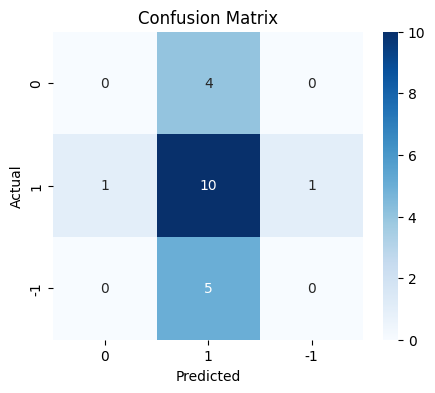

```python
plot_confusion_matrix(base_wv, X_val_wv, y_val)
```

```python
# Calculating different metrics on training data
base_train_wv = model_performance_classification_sklearn(base_wv, X_train_wv, y_train)
print("Training performance:\n", base_train_wv)
```

```
Training performance:
    Accuracy  Recall  Precision   F1
0       1.0     1.0        1.0  1.0
```

```python
# Calculating different metrics on validation data
base_val_wv = model_performance_classification_sklearn(base_wv, X_val_wv, y_val)
print("Validation performance:\n", base_val_wv)
```

```
Validation performance:
    Accuracy   Recall  Precision        F1
0   0.47619  0.47619   0.300752  0.368664
```

### Base Model - GloVe

```python
# Building the model

# Uncomment only one of the snippets related to fitting the model to the data
base_wv = GradientBoostingClassifier(random_state=42)
# base_wv = RandomForestClassifier(random_state=42)
# base_wv = DecisionTreeClassifier(random_state=42)

# Fitting on train data
base_wv.fit(
    X_train_gl, y_train
)  # Complete the code to fit the chosen model on the train data
```

```
GradientBoostingClassifier(random_state=42)
```

```python
plot_confusion_matrix(
    base_wv, X_train_gl, y_train
)  # Complete the code to plot the confusion matrix for the train data
```

[output not shown]

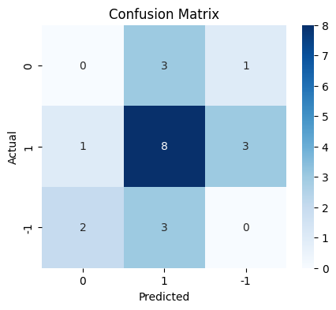

```python
plot_confusion_matrix(
    base_wv, X_val_gl, y_val
)  # Complete the code to plot the confusion matrix for the train data
```

```python
# Calculating different metrics on training data
base_train_gl = model_performance_classification_sklearn(
    base_wv, X_train_gl, y_train
)  # Complete the code to compute the model performance for the training data
print("Training performance:\n", base_train_gl)
```

```
Training performance:
    Accuracy  Recall  Precision   F1
0       1.0     1.0        1.0  1.0
```

```python
# Calculating different metrics on training data
base_val_gl = model_performance_classification_sklearn(
    base_wv, X_val_gl, y_val
)  # Complete the code to compute the model performance for the training data
print("Val performance:\n", base_val_gl)
```

```
Val performance:
    Accuracy    Recall  Precision        F1
0  0.380952  0.380952   0.326531  0.351648
```

### Base Model - Sentence Transformer

```python
# Building the model

# Uncomment only one of the snippets related to fitting the model to the data

base_wv = GradientBoostingClassifier(random_state=42)
# base_wv = RandomForestClassifier(random_state=42)
# base_wv = DecisionTreeClassifier(random_state=42)

# Fitting on train data
base_wv.fit(
    X_train_st, y_train
)  # Complete the code to fit the chosen model on the train data
```

```
GradientBoostingClassifier(random_state=42)
```

```python
plot_confusion_matrix(
    base_wv, X_train_st, y_train
)  # Complete the code to plot the confusion matrix for the train data
```

[output not shown]

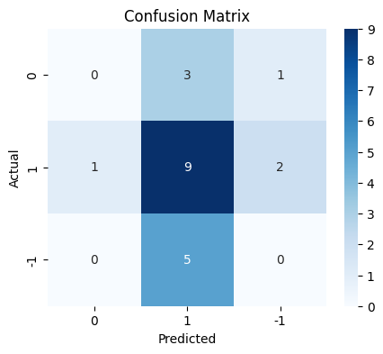

```python
plot_confusion_matrix(
    base_wv, X_val_st, y_val
)  # Complete the code to plot the confusion matrix for the train data
```

```python
# Calculating different metrics on training data
base_train_st = model_performance_classification_sklearn(
    base_wv, X_train_st, y_train
)  # Complete the code to compute the model performance for the training data
print("Training performance:\n", base_train_st)
```

```
Training performance:
    Accuracy  Recall  Precision   F1
0       1.0     1.0        1.0  1.0
```

```python
# Calculating different metrics on training data
base_val_st = model_performance_classification_sklearn(
    base_wv, X_val_st, y_val
)  # Complete the code to compute the model performance for the training data
print("Validaiotn performance:\n", base_val_st)
```

```
Validaiotn performance:
    Accuracy    Recall  Precision       F1
0  0.428571  0.428571   0.302521  0.35468
```

### Tuned Model - Word2Vec

```python
start = time.time()

# Choose the type of classifier.

# Uncomment only one of the snippets corrrsponding to the base model trained previously

tuned_wv = GradientBoostingClassifier(random_state=42)
# tuned_wv = RandomForestClassifier(random_state=42)
# tuned_wv = DecisionTreeClassifier(random_state=42)


parameters = {
    "max_depth": np.arange(3, 7),
    "min_samples_split": np.arange(5, 12, 2),
    "max_features": ["log2", "sqrt", 0.2, 0.4],
}

# Run the grid search
grid_obj = GridSearchCV(tuned_wv, parameters, scoring="f1_weighted", cv=5, n_jobs=-1)
grid_obj = grid_obj.fit(X_train_wv, y_train)

end = time.time()
print("Time taken ", (end - start))

# Set the clf to the best combination of parameters
tuned_wv = grid_obj.best_estimator_
```

```
Time taken  54.61057734489441
```

```python
# Fit the best algorithm to the data.
tuned_wv.fit(X_train_wv, y_train)
```

```
GradientBoostingClassifier(max_features=0.2, min_samples_split=9,
                           random_state=42)
```

```python
plot_confusion_matrix(tuned_wv, X_train_wv, y_train)
```

[output not shown]

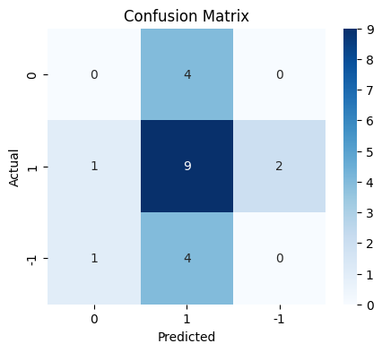

```python
plot_confusion_matrix(tuned_wv, X_val_wv, y_val)
```

```python
# Calculating different metrics on training data
tuned_train_wv = model_performance_classification_sklearn(tuned_wv, X_train_wv, y_train)
print("Training performance:\n", tuned_train_wv)
```

```
Training performance:
    Accuracy  Recall  Precision   F1
0       1.0     1.0        1.0  1.0
```

```python
# Calculating different metrics on validation data
tuned_val_wv = model_performance_classification_sklearn(tuned_wv, X_val_wv, y_val)
print("Validation performance:\n", tuned_val_wv)
```

```
Validation performance:
    Accuracy    Recall  Precision       F1
0  0.428571  0.428571   0.302521  0.35468
```

### Tuned Model - GloVe

```python
start = time.time()

# Uncomment only one of the snippets corrrsponding to the base model trained previously

tuned_wv = GradientBoostingClassifier(random_state=42)
# tuned_wv = RandomForestClassifier(random_state=42)
# tuned_wv = DecisionTreeClassifier(random_state=42)

parameters = {
    "max_depth": np.arange(3, 7),
    "min_samples_split": np.arange(5, 12, 2),
    "max_features": ["log2", "sqrt", 0.2, 0.4],
}

# Run the grid search
grid_obj = GridSearchCV(
    tuned_wv, parameters, scoring="f1_weighted", cv=5, n_jobs=-1
)  # Complete the code to pass the chosen model
grid_obj = grid_obj.fit(X_train_gl, y_train)

end = time.time()
print("Time taken ", (end - start))

# Set the clf to the best combination of parameters
tuned_gl = grid_obj.best_estimator_
```

```
Time taken  22.70349669456482
```

```python
# Fit the best algorithm to the data.
tuned_gl.fit(
    X_train_gl, y_train
)  # Complete the code to fit the chosen model on the train data
```

```
GradientBoostingClassifier(max_features='log2', min_samples_split=9,
                           random_state=42)
```

```python
plot_confusion_matrix(tuned_gl, X_train_gl, y_train)
```

[output not shown]

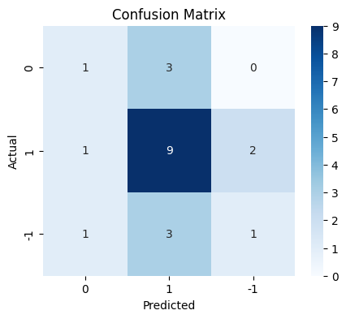

```python
plot_confusion_matrix(tuned_gl, X_val_gl, y_val)
```

```python
# Calculating different metrics on training data
tuned_train_gl = model_performance_classification_sklearn(tuned_gl, X_train_gl, y_train)
print("Training performance:\n", tuned_train_gl)
```

```
Training performance:
    Accuracy  Recall  Precision   F1
0       1.0     1.0        1.0  1.0
```

```python
# Calculating different metrics on training data
tuned_val_gl = model_performance_classification_sklearn(tuned_gl, X_val_gl, y_val)
print("Val performance:\n", tuned_val_gl)
```

```
Val performance:
    Accuracy   Recall  Precision        F1
0   0.52381  0.52381   0.485714  0.494898
```

### Tuned Model - Sentence Transformer

```python
start = time.time()

# Choose the type of classifier.

# Uncomment only one of the snippets corrrsponding to the base model trained previously
tuned_wv = GradientBoostingClassifier(random_state=42)
# tuned_wv = RandomForestClassifier(random_state=42)
# tuned_wv = DecisionTreeClassifier(random_state=42)

parameters = {
    "max_depth": np.arange(3, 7),
    "min_samples_split": np.arange(5, 12, 2),
    "max_features": ["log2", "sqrt", 0.2, 0.4],
}

# Run the grid search
grid_obj = GridSearchCV(
    tuned_wv, parameters, scoring="f1_weighted", cv=5, n_jobs=-1
)  # Complete the code to pass the chosen model
grid_obj = grid_obj.fit(X_train_st, y_train)

end = time.time()
print("Time taken ", (end - start))

# Set the clf to the best combination of parameters
tuned_st = grid_obj.best_estimator_
```

```
Time taken  64.42252683639526
```

```python
# Fit the best algorithm to the data.
tuned_st.fit(
    X_train_st, y_train
)  # Complete the code to fit the chosen model on the train data
```

```
GradientBoostingClassifier(max_features='sqrt', min_samples_split=5,
                           random_state=42)
```

```python
plot_confusion_matrix(
    tuned_st, X_train_st, y_train
)  # Complete the code to plot the confusion matrix for the train data
```

[output not shown]

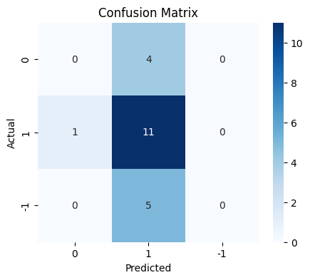

```python
plot_confusion_matrix(
    tuned_st, X_val_st, y_val
)  # Complete the code to plot the confusion matrix for the train data
```

```python
# Calculating different metrics on training data
tuned_train_st = model_performance_classification_sklearn(
    tuned_st, X_train_st, y_train
)  # Complete the code to compute the model performance for the training data
print("Training performance:\n", tuned_train_st)
```

```
Training performance:
    Accuracy  Recall  Precision   F1
0       1.0     1.0        1.0  1.0
```

```python
# Calculating different metrics on validation data
tuned_val_st = model_performance_classification_sklearn(
    tuned_st, X_val_st, y_val
)  # Complete the code to compute the model performance for the validation data
print("Validation performance:\n", tuned_val_st)
```

```
Validation performance:
    Accuracy   Recall  Precision        F1
0   0.52381  0.52381   0.314286  0.392857
```

```python
# training performance comparison

models_train_comp_df = pd.concat(
    [
        base_train_wv.T,
        base_train_gl.T,
        base_train_st.T,
        tuned_train_wv.T,
        tuned_train_gl.T,
        tuned_train_st.T,
    ],
    axis=1,
)

models_train_comp_df.columns = [
    "Base Model (Word2Vec)",
    "Base Model (GloVe)",
    "Base Model (Sentence Transformer)",
    "Tuned Model (Word2Vec)",
    "Tuned Model (GloVe)",
    "Tuned Model (Sentence Transformer)",
]

print("Training performance comparison:")
models_train_comp_df
```

```
Training performance comparison:
```

|  | Base Model (Word2Vec) | Base Model (GloVe) | Base Model (Sentence Transformer) | Tuned Model (Word2Vec) | Tuned Model (GloVe) | Tuned Model (Sentence Transformer) |
| --- | --- | --- | --- | --- | --- | --- |
| Accuracy | 1.0 | 1.0 | 1.0 | 1.0 | 1.0 | 1.0 |
| Recall | 1.0 | 1.0 | 1.0 | 1.0 | 1.0 | 1.0 |
| Precision | 1.0 | 1.0 | 1.0 | 1.0 | 1.0 | 1.0 |
| F1 | 1.0 | 1.0 | 1.0 | 1.0 | 1.0 | 1.0 |

```python
# validation performance comparison

models_val_comp_df = pd.concat(
    [
        base_val_wv.T,
        base_val_gl.T,
        base_val_st.T,
        tuned_val_wv.T,
        tuned_val_gl.T,
        tuned_val_st.T,
    ],
    axis=1,
)

models_val_comp_df.columns = [
    "Base Model (Word2Vec)",
    "Base Model (GloVe)",
    "Base Model (Sentence Transformer)",
    "Tuned Model (Word2Vec)",
    "Tuned Model (GloVe)",
    "Tuned Model (Sentence Transformer)",
]

print("Validation performance comparison:")
models_val_comp_df
```

```
Validation performance comparison:
```

|  | Base Model (Word2Vec) | Base Model (GloVe) | Base Model (Sentence Transformer) | Tuned Model (Word2Vec) | Tuned Model (GloVe) | Tuned Model (Sentence Transformer) |
| --- | --- | --- | --- | --- | --- | --- |
| Accuracy | 0.476190 | 0.380952 | 0.428571 | 0.428571 | 0.523810 | 0.523810 |
| Recall | 0.476190 | 0.380952 | 0.428571 | 0.428571 | 0.523810 | 0.523810 |
| Precision | 0.300752 | 0.326531 | 0.302521 | 0.302521 | 0.485714 | 0.314286 |
| F1 | 0.368664 | 0.351648 | 0.354680 | 0.354680 | 0.494898 | 0.392857 |

## **Weekly News Summarization**

**Important Note**: It is recommended to run this section of the project independently from the previous sections in order to avoid runtime crashes due to RAM overload.

#### Installing and Importing the necessary libraries

```python
# Installation for GPU llama-cpp-python
# uncomment and run the following code in case GPU is being used
!CMAKE_ARGS="-DLLAMA_CUBLAS=on" FORCE_CMAKE=1 pip install llama-cpp-python -q

# Installation for CPU llama-cpp-python
# uncomment and run the following code in case GPU is not being used
#!CMAKE_ARGS="-DLLAMA_CUBLAS=off" FORCE_CMAKE=1 pip install llama-cpp-python -q
```

[output not shown]

```python
%pip install llama-cpp-python
```

```python
# Function to download the model from the Hugging Face model hub
from huggingface_hub import hf_hub_download

# Importing the Llama class from the llama_cpp module
from llama_cpp import Llama

# Importing the library for data manipulation
import pandas as pd

from tqdm import tqdm  # For progress bar related functionalities

tqdm.pandas()
```

#### Loading the data

```python
# Now let's import and put the train and test datasets in  pandas dataframe
folderPath = "./inputs"

stock_news = pd.read_csv(
    folderPath + "/stock_news.csv"
)  # Complete the code to read the CSV file.
```

```python
data = stock_news.copy()
```

#### Loading the model

```python
model_name_or_path = "TheBloke/Mistral-7B-Instruct-v0.2-GGUF"
model_basename = "mistral-7b-instruct-v0.2.Q6_K.gguf"


model_path = hf_hub_download(
    repo_id=model_name_or_path,  # Complete the code to mention the repo_id
    filename=model_basename,  # Complete the code to mention the filename
)
```

#### Aggregating the data weekly

```python
data["Date"] = pd.to_datetime(
    data["Date"]
)  # Convert the 'Date' column to datetime format.
```

```python
# Group the data by week using the 'Date' column.
weekly_grouped = data.groupby(pd.Grouper(key="Date", freq="W"))
```

```python
weekly_grouped = weekly_grouped.agg(
    {"News": lambda x: " || ".join(x)}  # Join the news values with ' || ' separator.
).reset_index()

print(weekly_grouped.shape)
```

```
(18, 2)
```

```python
weekly_grouped
```

|  | Date | News |
| --- | --- | --- |
| 0 | 2019-01-06 | The tech sector experienced a significant dec... |
| 1 | 2019-01-13 | Sprint and Samsung plan to release 5G smartph... |
| 2 | 2019-01-20 | The U.S. stock market declined on Monday as c... |
| 3 | 2019-01-27 | The Swiss National Bank (SNB) governor, Andre... |
| 4 | 2019-02-03 | Caterpillar Inc reported lower-than-expected ... |
| 5 | 2019-02-10 | The Dow Jones Industrial Average, S&P 500, an... |
| 6 | 2019-02-17 | This week, the European Union's second highes... |
| 7 | 2019-02-24 | This news article discusses progress towards ... |
| 8 | 2019-03-03 | The Dow Jones Industrial Average and other ma... |
| 9 | 2019-03-10 | Spotify, the world's largest paid music strea... |
| 10 | 2019-03-17 | The United States opposes France's digital se... |
| 11 | 2019-03-24 | Facebook's stock price dropped more than 3% o... |
| 12 | 2019-03-31 | This news article reports that the S&P 500 In... |
| 13 | 2019-04-07 | Apple and other consumer brands, including LV... |
| 14 | 2019-04-14 | In March, mobile phone shipments to China dro... |
| 15 | 2019-04-21 | The chairman of Taiwan's Foxconn, Terry Gou, ... |
| 16 | 2019-04-28 | Taiwan's export orders continued to decline f... |
| 17 | 2019-05-05 | Spotify reported better-than-expected Q1 reve... |

```python
# creating a copy of the data
data_1 = weekly_grouped.copy()
```

#### Summarization

**Note**:

- The model is expected to summarize the news from the week by identifying the top three positive and negative events that are most likely to impact the price of the stock.
- As an output, the model is expected to return a JSON containing two keys, one for Positive Events and one for Negative Events.

For the project, we need to define the prompt to be fed to the LLM to help it understand the task to perform. The following should be the components of the prompt:

1. **Role**: Specifies the role the LLM will be taking up to perform the specified task, along with any specific details regarding the role
- **Example**: `You are an expert data analyst specializing in news content analysis.`
2. **Task**: Specifies the task to be performed and outlines what needs to be accomplished, clearly defining the objective
- **Example**: `Analyze the provided news headline and return the main topics contained within it.`
3. **Instructions**: Provides detailed guidelines on how to perform the task, which includes steps, rules, and criteria to ensure the task is executed correctly
- **Example**:

```
Instructions:
1. Read the news headline carefully.
2. Identify the main subjects or entities mentioned in the headline.
3. Determine the key events or actions described in the headline.
4. Extract relevant keywords that represent the topics.
5. List the topics in a concise manner.
```

4. **Output Format**: Specifies the format in which the final response should be structured, ensuring consistency and clarity in the generated output
- **Example**: `Return the output in JSON format with keys as the topic number and values as the actual topic.`

**Full Prompt Example**:

```
You are an expert data analyst specializing in news content analysis.

Task: Analyze the provided news headline and return the main topics contained within it.

Instructions:
1. Read the news headline carefully.
2. Identify the main subjects or entities mentioned in the headline.
3. Determine the key events or actions described in the headline.
4. Extract relevant keywords that represent the topics.
5. List the topics in a concise manner.

Return the output in JSON format with keys as the topic number and values as the actual topic.
```

**Sample Output**:

`{"1": "Politics", "2": "Economy", "3": "Health" }`

##### Utility Functions

```python
# defining a function to parse the JSON output from the model
def extract_json_data(json_str):
    import json

    try:
        # Find the indices of the opening and closing curly braces
        json_start = json_str.find("{")
        json_end = json_str.rfind("}")

        if json_start != -1 and json_end != -1:
            extracted_category = json_str[
                json_start : json_end + 1
            ]  # Extract the JSON object
            data_dict = json.loads(extracted_category)
            return data_dict
        else:
            print(f"Warning: JSON object not found in response: {json_str}")
            return {}
    except json.JSONDecodeError as e:
        print(f"Error parsing JSON: {e}")
        return {}
```

```python
# uncomment the below snippet of code if the runtime is connected to GPU.
llm = Llama(
    model_path=model_path,  # Path to the model
    n_gpu_layers=100,  # Number of layers transferred to GPU
    n_ctx=4500,  # Context window
)
```

[output not shown]

[output cut: 46 more lines]

[output not shown]

##### Defining the response function

```python
# Defining the response function
def response_mistral_1(prompt, news):
    model_output = llm(
        f"""
      [INST]
      {prompt}
      News Articles: {news}
      [/INST]
      """,
        max_tokens=1024,  # Complete the code to set the maximum number of tokens the model should generate for this task.
        temperature=0,  # Complete the code to set the value for temperature.
        top_p=0.95,  # Complete the code to set the value for top_p
        top_k=50,  # Complete the code to set the value for top_k
        echo=False,
    )

    final_output = model_output["choices"][0]["text"]

    return final_output
```

##### Checking the model output on a sample

**Note**: Use this section to test out the prompt with one instance before using it for the entire weekly data.

```python
news = data_1.loc[2, "News"]
news
```

```
' The U.S. stock market declined on Monday as concerns over a global economic slowdown intensified following unexpected drops in China\'s exports and imports, with tech stocks suffering the most significant losses. The Philadelphia SE Semiconductor Index fell 1.6 percent, while the technology sector…
```

```python
# print(len(news.split(" ")))
# # news
```

```python
# Complete the code to define the prompt for this task
prompt = """
  process this news article and extract Top 3 Positive News and Top 3 Negative News in summarized form.
  Convert the reply to a well formed JSON format like this
   "Top 3 Positive News": [
           {
             "Summary": "Roku is following Amazon's successful Channels business model by offering premium video channels on a subscription basis through its free streaming service."
           }
"""
```

```python
%%time
summary = response_mistral_1(prompt, news)
print(summary)
```

```
llama_perf_context_print:        load time =   82654.85 ms
llama_perf_context_print: prompt eval time =       0.00 ms /  2195 tokens (    0.00 ms per token,      inf tokens per second)
llama_perf_context_print:        eval time =       0.00 ms /   383 runs   (    0.00 ms per token,      inf tokens per second)
llama_perf_context_print:       total time =  124360.57 ms /  2578 tokens
```

```
 "Top 3 Positive News": [
           {
             "Summary": "Apple and Netflix led tech stocks higher on Tuesday, contributing to a rise in U.S. stocks. The S&P 500 communication services and technology indices surged."
           },
           {
             "Summary": "Verizon expanded its partnership with Apple, offering free Apple Music subscriptions with some top tier data plans. Apple is turning to its services segment for growth and has been partnering with rivals such as Samsung and Amazon."
           },
           {
             "Summary": "Belarus introduced a new platform enabling investors to buy real assets using cryptocurrencies. The platform plans to issue 10,000 tokens representing traditional financial instruments, with current offerings including gold, oil, and metals."
           }
       ],

       "Top 3 Negative News": [
           {
             "Summary": "U.S. stocks declined on Monday due to concerns over a global economic slowdown, with tech stocks suffering the most significant losses. The weak Chinese trade data led to a halt in Europe's stock market rally."
           },
           {
             "Summary": "China's auto market experienced its first contraction since the 1990s in 2018, with sales falling 2.8 percent to 28.1 million vehicles due to the phasing out of purchase tax cuts on smaller cars and the US-China trade war."
           },
           {
             "Summary": "Apple faces a ban on some iPhones in China and a patent lawsuit loss against Qualcomm. The company is also dealing with rumors of potential cuts to its self-driving vehicle program."
           }
       ]
    }
CPU times: total: 22min 35s
Wall time: 2min 4s
```

```python
summary
```

```
' "Top 3 Positive News": [\n           {\n             "Summary": "Apple and Netflix led tech stocks higher on Tuesday, contributing to a rise in U.S. stocks. The S&P 500 communication services and technology indices surged."\n           },\n           {\n             "Summary": "Verizon expanded it…
```

```python
summary1 = extract_json_data(summary)
summary1
```

```
Error parsing JSON: Extra data: line 3 column 13 (char 198)
```

```
{}
```

##### Checking the model output on the weekly data

```python
# data_2 = data_1[2:3]
data_2 = data_1
```

```python
# data_2
```

```python
%%time
data_2['Key Events'] = data_2['News'].progress_apply(lambda x: response_mistral_1(prompt,x))
```

[output not shown]

[output cut: 17 more lines]

[output not shown]

```
CPU times: total: 4h 38min 35s
Wall time: 26min 26s
```

```python
data_2["Key Events"].head(
    5
)  # Complete the code to print the first 5 rows of the 'Key_Events' column
print(data_2["Key Events"])
# data_2.to_csv('output.csv', index=False)
```

```
0      {\n         "Top 3 Positive News": [\n       ...
1      {\n         "Top 3 Positive News": [\n       ...
2      "Top 3 Positive News": [\n           {\n     ...
3      {\n         "Top 3 Positive News": [\n       ...
4      "Top 3 Positive News": [\n           {\n     ...
5      {\n         "Top 3 Positive News": [\n       ...
6      "Top 3 Positive News": [\n           {\n     ...
7      {\n         "Top 3 Positive News": [\n       ...
8      {\n         "Top 3 Positive News": [\n       ...
9      {\n         "Top 3 Positive News": [\n       ...
10     "Top 3 Positive News": [\n           {\n     ...
11     "Top 3 Positive News": [\n           {\n     ...
12     "Top 3 Positive News": [\n           {\n     ...
13     {\n         "Top 3 Positive News": [\n       ...
14     {\n         "Top 3 Positive News": [\n       ...
15     {\n         "Top 3 Positive News": [\n       ...
16     {\n         "Top 3 Positive News": [\n       ...
17     {\n         "Top 3 Positive News": [\n       ...
Name: Key Events, dtype: object
```

##### Formatting the model output

```python
data_2["model_response_parsed"] = data_2["Key Events"].apply(extract_json_data)
data_2.head()
```

```
Error parsing JSON: Extra data: line 3 column 13 (char 198)
Error parsing JSON: Expecting property name enclosed in double quotes: line 8 column 12 (char 472)
Error parsing JSON: Extra data: line 3 column 13 (char 167)
Error parsing JSON: Expecting property name enclosed in double quotes: line 16 column 12 (char 700)
Error parsing JSON: Extra data: line 3 column 13 (char 258)
Error parsing JSON: Extra data: line 3 column 13 (char 218)
Error parsing JSON: Extra data: line 3 column 13 (char 162)
Error parsing JSON: Extra data: line 3 column 13 (char 218)
Error parsing JSON: Expecting property name enclosed in double quotes: line 8 column 12 (char 421)
```

|  | Date | News | Key Events | model_response_parsed |
| --- | --- | --- | --- | --- |
| 0 | 2019-01-06 | The tech sector experienced a significant dec... | {\n "Top 3 Positive News": [\n ... | {'Top 3 Positive News': [{'Summary': 'Roku is ... |
| 1 | 2019-01-13 | Sprint and Samsung plan to release 5G smartph... | {\n "Top 3 Positive News": [\n ... | {'Top 3 Positive News': [{'Summary': 'Sprint a... |
| 2 | 2019-01-20 | The U.S. stock market declined on Monday as c... | "Top 3 Positive News": [\n {\n ... | {} |
| 3 | 2019-01-27 | The Swiss National Bank (SNB) governor, Andre... | {\n "Top 3 Positive News": [\n ... | {} |
| 4 | 2019-02-03 | Caterpillar Inc reported lower-than-expected ... | "Top 3 Positive News": [\n {\n ... | {} |

```python
model_response_parsed = pd.json_normalize(data_2["model_response_parsed"])
model_response_parsed.head()
```

|  | Top 3 Positive News | Top 3 Negative News |
| --- | --- | --- |
| 0 | [{'Summary': 'Roku is offering premium video c... | [{'Summary': 'Apple cut its quarterly revenue ... |
| 1 | [{'Summary': 'Sprint and Samsung plan to relea... | [{'Summary': 'Geely, China's most successful c... |
| 2 | NaN | NaN |
| 3 | NaN | NaN |
| 4 | NaN | NaN |

```python
final_output = pd.concat([data_2.reset_index(drop=True), model_response_parsed], axis=1)
final_output.drop(["Key Events", "model_response_parsed"], axis=1, inplace=True)
final_output.columns = [
    "Week End Date",
    "News",
    "positive_events",
    "negative_events",
]

final_output.head()
```

|  | Week End Date | News | positive_events | negative_events |
| --- | --- | --- | --- | --- |
| 0 | 2019-01-06 | The tech sector experienced a significant dec... | [{'Summary': 'Roku is offering premium video c... | [{'Summary': 'Apple cut its quarterly revenue ... |
| 1 | 2019-01-13 | Sprint and Samsung plan to release 5G smartph... | [{'Summary': 'Sprint and Samsung plan to relea... | [{'Summary': 'Geely, China's most successful c... |
| 2 | 2019-01-20 | The U.S. stock market declined on Monday as c... | NaN | NaN |
| 3 | 2019-01-27 | The Swiss National Bank (SNB) governor, Andre... | NaN | NaN |
| 4 | 2019-02-03 | Caterpillar Inc reported lower-than-expected ... | NaN | NaN |

## **Conclusions and Recommendations**

- Prompt Engineering can help improve or tune the output
- Different LLM models can be tried to see which provides better output like Google Gemini, Anthropic etc

Power Ahead